# Concise Essay 1

Shaila Ang

30 October, 2020

# Acupuncture for headache

A study by Vickers et al., published in the British Medical Journal in 2004, investigated the use of acupuncture for chronic headache in primary care in a large, randomised trial.  
The data from this study provides the basis for this concise essay.

This essay provides visualisations of major outcomes considered by the study at 3 and 12 months. The outcomes of interest are headache severity score and headache frequency.

# Treatments

The study measured the effectiveness of acupuncture for chronic headache in primary care using two treatments labelled ‘usual care’ and ‘acupuncture group’. The eligible patients completed a baseline headache diary for four weeks and were randomised according to “use acupuncture” or “avoid acupuncture”. During a 3 month period, patients in the “use acupuncture” group received four acupuncture treatments per month from qualified professionals, and the acupuncture point prescriptions were unique to each person. This was in addition to the standard care from their GPs, whereas the “avoid acupuncture” group only received standard care and were never referred to acupuncture specialists.

```
## For best results, restart R session and update pander using devtools:: or remotes::install_github('rapporter/pander')
```

# Age of participants

The plot below shows a histogram of the age of the participants in the study.

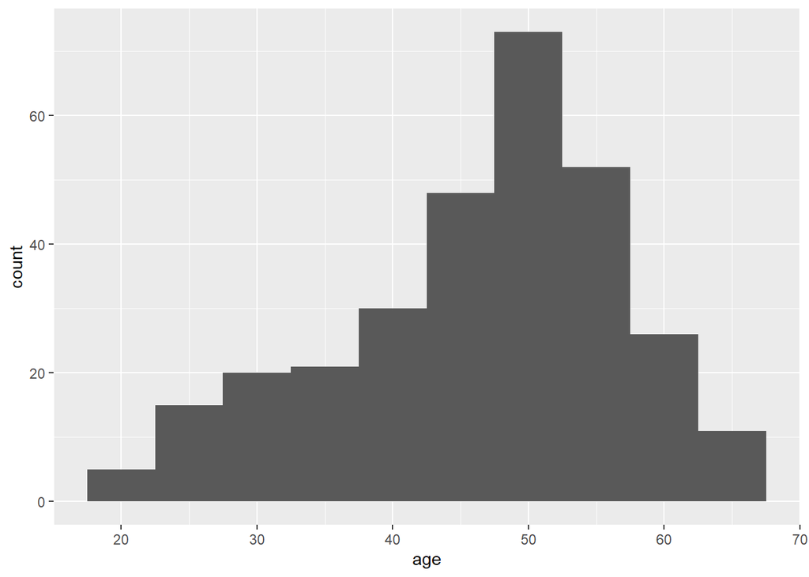

```r
plot1 <- ggplot(acupuncture_for_headache, aes(x = age)) +
      geom_histogram(binwidth=5)
plot1
```

# Headache frequency at 3 months

A daily diary was completed by patients over a four week period at three different stages of the study. The frequency was linked to the severity in a six-point Likert scale, where 5 equalled the most severe headache and 0 represented no headache at all. These were recorded 4 times per day, and this total provided an overall headache score. Additional health status questionnaires were also completed across the 12 month period at quarterly intervals, and after 12 months, patients were also asked to provide an estimate of headache severity on a different scale, which further provided indications of headache frequency in the cohort.

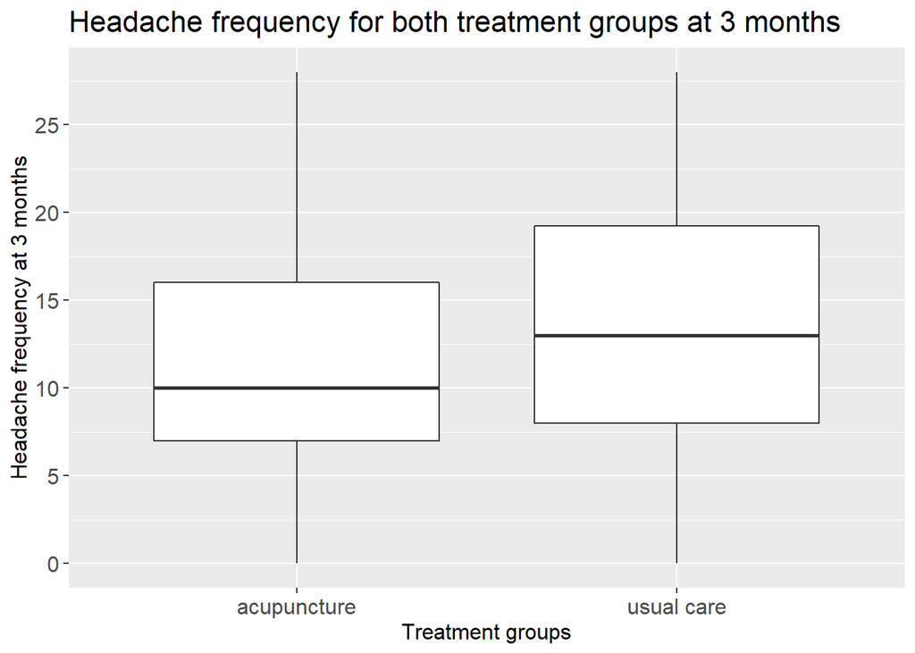

```r
Theme1 <- theme(axis.title.x = element_text(size=12),
                axis.text.x  = element_text(size=12),
                axis.title.y = element_text(size=12),
                axis.text.y  = element_text(size=12),
                plot.title = element_text(size = 16),
                strip.text = element_text(size = 12))

graph1 <- ggplot(acupuncture_for_headache,aes(x=group,  y=as.numeric(f2))) +
  geom_boxplot() +
  labs(
    x = "Treatment groups",
    y = "Headache frequency at 3 months",
    title = paste(
      "Headache frequency for both treatment groups at 3 months"
    )
  ) +
  scale_y_continuous(breaks = scales::pretty_breaks(n = 10)) +
  Theme1
graph1
```

# Headache severity at 12 months

The headache severity was linked to the frequency and was recorded four times a day across a four week period to create a baseline, then at 3 months and 12 months after randomisation. The diary used a six-point Likert scale ranging from ‘no headache’ to ‘intense incapacitating’, which summed up to give the total headache score. Patients also completed the SF36 health status questionnaire at baseline, three months, and one year. Along with additional questionnaires throughout the study period, after 12 months patients also provided an estimate of their current and baseline headache severity on a scale of 1-10.

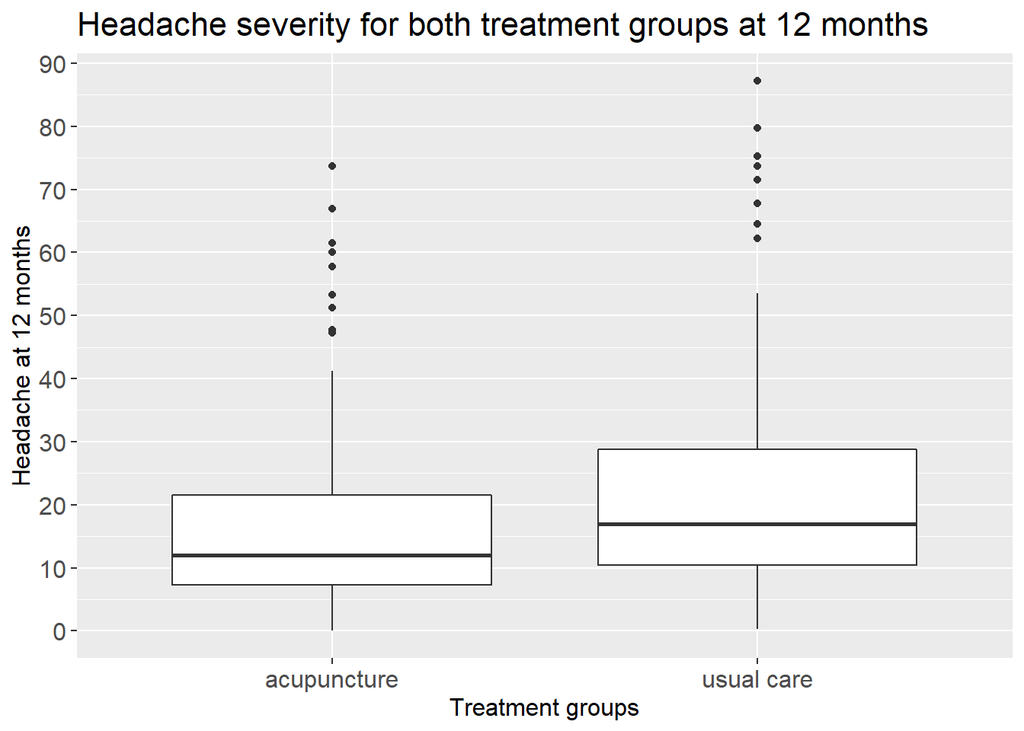

```r
graph2 <- ggplot(acupuncture_for_headache,aes(x=group,  y=as.numeric(pk5))) +
  geom_boxplot() +
  labs(
    x = "Treatment groups",
    y = "Headache at 12 months",
    title = paste(
      "Headache severity for both treatment groups at 12 months"
    )
  ) +
  scale_y_continuous(breaks = scales::pretty_breaks(n = 10)) +
  Theme1
graph2
```